# DSCI 310 Project Group 7

Jade Chen, Jessica Luo, Heidi Lantz, and Nazia Edroos

# Predicting Age from Drug Use Patterns: A Statistical Analysis

## Summary

This study explores the relationship between drug use and age, aiming to determine whether a person’s reported substance use can serve as a reliable predictor of their age. Using the “Drug Use by Age” dataset from FiveThirtyEight, which compiles data from the National Survey on Drug Use and Health (Services 2013), we employ statistical techniques to analyze the relationship between age and substance use. The dataset contains information about a given age group, and summary info about the percentage of people who have done a drug and the median frequency it is used at. There is information on a wide variety of drugs, including alcohol, marijuana, various illicit drugs, and more. We apply feature selection and predictive modeling to assess the strength of this relationship.

Our findings suggest that while age-related trends in substance use are present, challenges such as class imbalance and small dataset size hinder the models’ ability to accurately predict age based solely on drug use. Despite these challenges, the analysis highlights the potential for using substance use patterns as part of a broader predictive framework in public health and policy contexts.

# Introduction

### Background and Research Question

Age can greatly influence many aspects of how we behave and what decisions we make, especially regarding substance use. Patterns of drug consumption change over time in a person’s life, reflecting their social, biological, and environmental influences. Research indicates that substance use disorders, including those related to alcohol, tobacco, cannabis, and opioids, generally decrease with age (Traci Green 2010). Younger individuals often engage in higher rates of substance experimentation, while older adults tend to exhibit more stable or declining usage patterns. Understanding these age-related trends is essential for developing effective public health strategies, addiction prevention programs, and targeted interventions.

In this study, we investigate whether a person’s reported drug use can serve as a predictor of their age (Services 2013). Previous research has highlighted the progression and predictors of substance use across the lifespan. For instance, studies have identified that early initiation of substance use is associated with an increased risk of developing substance use disorders later in life (Irma Arteaga 2010). Furthermore, patterns observed during adolescence are often associated with continued use or potential abuse in adulthood (Joseph Allen 2021). This tells us that finding out which age groups are using which drugs can be useful information for addressing and preventing issues like this. Moreover, life-course patterns of substance abuse reveal that older adults with substance misuse issues often reflect on their usage patterns, providing insights into the development and persistence of these behaviors over time (Caitlin Foster 2019). Recognizing these patterns across different age groups can inform the creation of age-specific prevention and treatment programs. By assessing the strength of the relationship between age and drug use behaviors, our analysis contributes to discussions on behavioral health and its implications.

**This leads us to our Research Question:**

- *Can we accurately predict if an individual is a Youth (Under 21) or Adult (21 & Over) based only on their reported patterns of substance use?*

### About the Data

To address our research question, we utilize the “Drug Use by Age” dataset sourced from [FiveThirtyEight’s repository](https://github.com/rudeboybert/fivethirtyeight/tree/master/data-raw/drug-use-by-age), which is derived from from the [2013 National Survey on Drug Use and Health](https://doi.org/10.3886/ICPSR35509.v3). This study was conducted by the United States Department of Health and Human Services, Substance Abuse and Mental Health Services Administration (SAMHSA), Center for Behavioral Health Statistics and Quality.

The dataset covers self-reported drug use trends across 17 age groups in the United States, examining 13 different substances. The dataset includes both legal substances, such as alcohol and marijuana, and illicit drugs, offering a broad perspective on substance use trends for each age group.

Below is a summary of the variables included in the dataset:

| Variable Name | Description |
| --- | --- |
| `age` | Age group of respondents (e.g., 12, ‘22-23’, ‘35-49’, ‘65+’ etc.). |
| `n` | Number of people surveyed in each age group. |
| `alcohol_use` | Percentage of respondents who used alcohol in the past 12 months. |
| `alcohol_frequency` | Median number of times alcohol was used in the past 12 months. |
| `marijuana_use` | Percentage who used marijuana in the past 12 months. |
| `marijuana_frequency` | Median number of times marijuana was used in the past 12 months. |
| `cocaine_use` | Percentage who used cocaine in the past 12 months. |
| `cocaine_frequency` | Median number of times cocaine was used in the past 12 months. |
| `crack_use` | Percentage who used crack in the past 12 months. |
| `crack_frequency` | Median number of times crack was used in the past 12 months. |
| `heroin_use` | Percentage who used heroin in the past 12 months. |
| `heroin_frequency` | Median number of times heroin was used in the past 12 months. |
| `hallucinogen_use` | Percentage who used hallucinogens in the past 12 months. |
| `hallucinogen_frequency` | Median number of times hallucinogens were used in the past 12 months. |
| `inhalant_use` | Percentage who used inhalants in the past 12 months. |
| `inhalant_frequency` | Median number of times inhalants were used in the past 12 months. |
| `pain_reliever_use` | Percentage who used pain relievers in the past 12 months. |
| `pain_reliever_frequency` | Median number of times pain relievers were used in the past 12 months. |
| `oxycontin_use` | Percentage who used OxyContin in the past 12 months. |
| `oxycontin_frequency` | Median number of times OxyContin was used in the past 12 months. |
| `tranquilizer_use` | Percentage who used tranquilizers in the past 12 months. |
| `tranquilizer_frequency` | Median number of times tranquilizers were used in the past 12 months. |
| `stimulant_use` | Percentage who used stimulants in the past 12 months. |
| `stimulant_frequency` | Median number of times stimulants were used in the past 12 months. |
| `meth_use` | Percentage who used methamphetamine in the past 12 months. |
| `meth_frequency` | Median number of times methamphetamine was used in the past 12 months. |
| `sedative_use` | Percentage who used sedatives in the past 12 months. |
| `sedative_frequency` | Median number of times sedatives were used in the past 12 months. |

# Methods & Results

### Read Data

We downloaded the dataset in `01-download-dataset.R` by retrieving it from a raw GitHub URL and saving it locally in the data/raw directory.

### Data Cleaning & Transformation

The dataset underwent the following preprocessing steps in `02-data-clean-transform.R`:

1. Replaced missing values: Instances of `-` in character columns were converted to `NA` to handle missing data appropriately.
2. Converted character columns to numeric: All character columns (except age) were coerced into numeric format, introducing `NA`s where conversion was not possible.
3. Created a new column, `class`, to classify participants as `youth` or `adult` based on their age, where individuals aged 20 or younger were classified as `youth` and those older than 20 were classified as `adult`.

### EDA

Since we aim to predict age category using drug use patterns, we performed some exploratory data analysis to gain a better understanding of our dataset in `03-eda.R`. We began by visualizing the proportion of individuals in each age group who have consumed alcohol in the past 12 months:

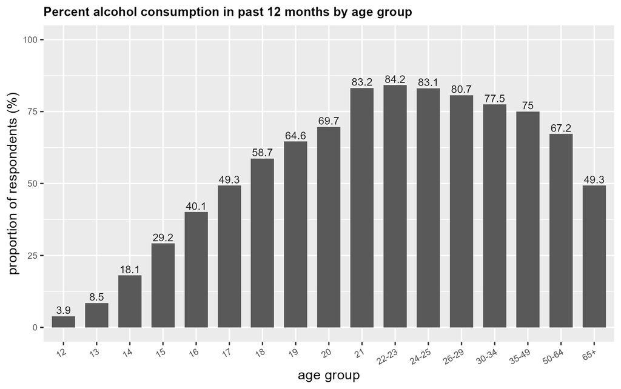

Proportion of individuals in each age group who have consumed alcohol in the past 12 months

We also applied the same approach to examine marijuana use over the same period:

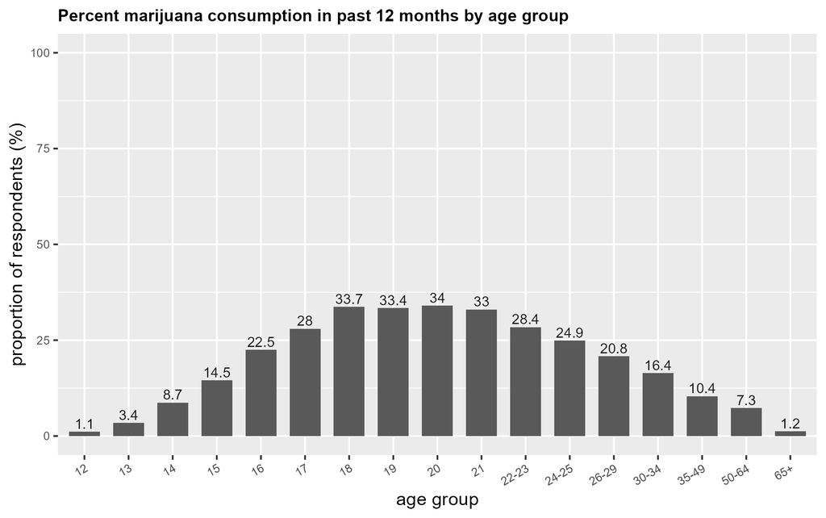

Proportion of individuals in each age group who have used marijuana in the past 12 months

Both graphs reveal that these substances are commonly used during adolescence. However, while alcohol consumption increases significantly in adulthood, marijuana use tends to plateau in early adulthood. To explore the use of hard drugs, such as heroin, crack and hallucinogens, we shift our focus to the median frequency of use rather than the proportion of users. This is because the proportion of individuals using harder substances is relatively small, making median frequency a more informative metric for understanding usage patterns. For instance, we can plot the distribution of heroin use across different age groups:

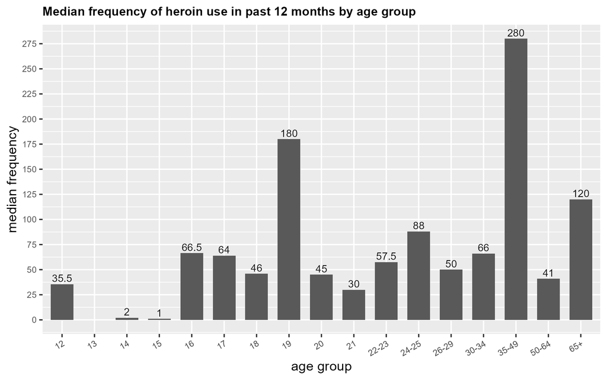

To explore the potential relationship between the frequency of heroin use and marijuana use among individuals, we used a scatter plot of each age group’s data points. We also added a linear regression line to help us determine whether there is any correlation between the two variables, and therefore whether heroin use is associated with marijuana use:

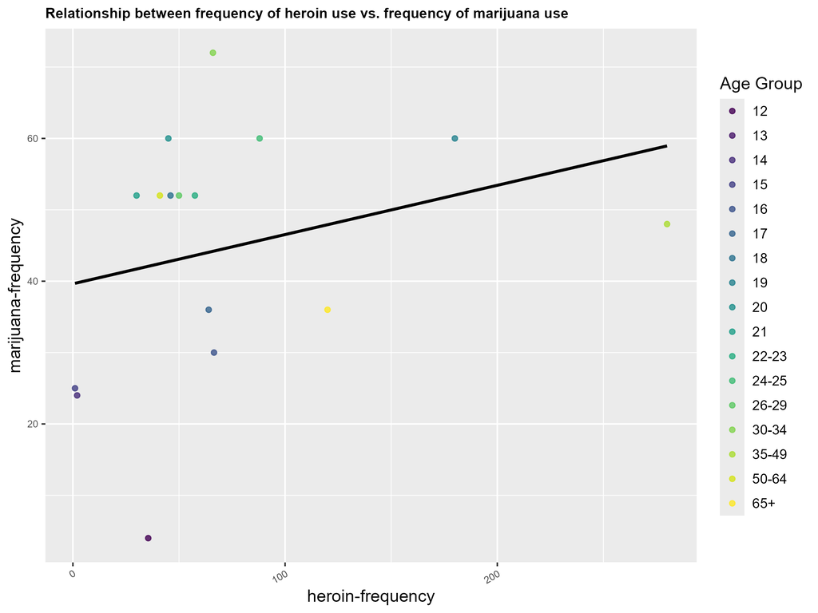

Relationship between frequency of heroin use vs. frequency of marijuana use

The motivation behind our research stems from the significant variation in substance use distribution based on the type of substance. Harder substances, in particular, exhibit distinct usage patterns compared to more commonly used substances like alcohol and marijuana. By analyzing these patterns, we aim to determine an individual’s age group (Under 21 or 21 & Over) based only on their reported substance use history. The insights gained from this research could inform prevention programs, helping them design targeted strategies to effectively advocate against drug abuse. This is especially critical for younger individuals, who are more susceptible to peer pressure and may benefit from early intervention.

### Potential Solutions

1. **Increase Dataset Size**  
   Collect more data to improve model performance.
2. **Feature Engineering**  
   Consider adding more relevant features or restructuring age-related data.
3. **Resampling Techniques**  
   Use bootstrapping or synthetic sampling (e.g., SMOTE) to balance class representation.

### Model Evaluation

Below are the confusion matrices for each model we tested:

1. Decision Tree

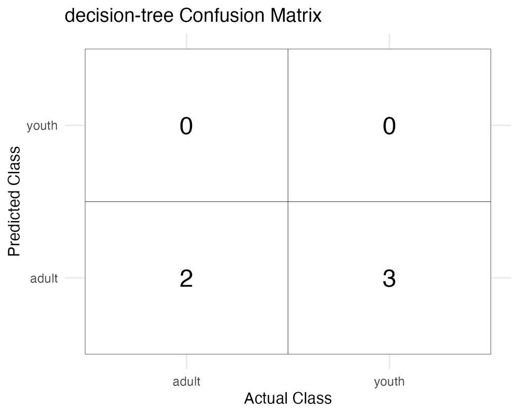

Confusion Matrix: Decision Tree

2. K Nearest Neighbours (KNN)

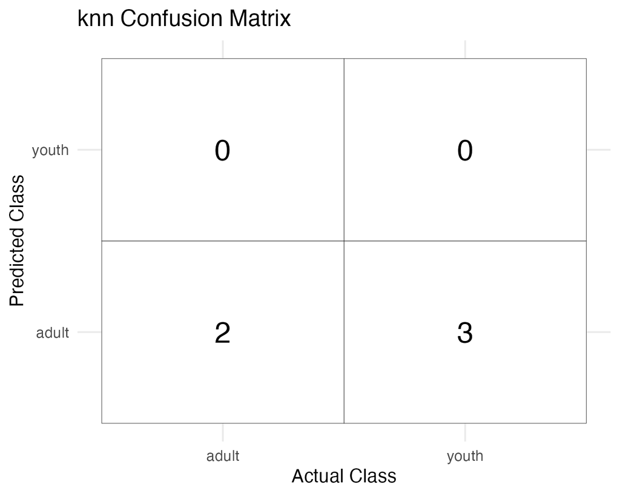

Confusion Matrix: KNN

3. Logistic Regression

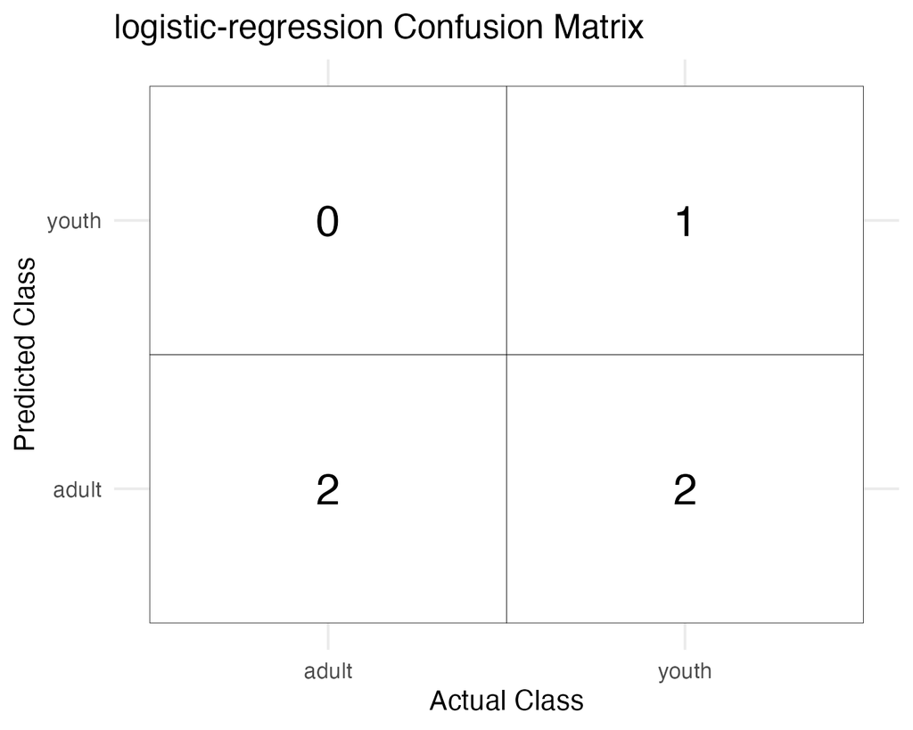

Confusion Matrix: Logistic Regression

# Discussion

### Findings

Our models struggled with accurately classifying youth vs. adult due to several key issues identified in the analysis. The small dataset size likely hindered the models’ ability to detect meaningful patterns. Additionally, the class imbalance between individual youth ages and adult age ranges made it difficult for the models to generalize and differentiate between these groups effectively. This was evident in the high rates of false positives, where youth were misclassified as adults. Lastly, the lack of feature variation beyond age likely contributed to the models’ poor performance, as age alone may not be sufficient to distinguish between youth and adult categories.

### Does This Align with Our Expectations?

Yes, these findings align with our expectations. Given the small dataset and the imbalance between the youth and adult classes, we anticipated that our models would struggle with classification accuracy. The confusion matrices for all three models—Decision Tree, KNN, and Logistic Regression—reflected the challenges we expected. The small dataset size likely exacerbated the issue, and the class imbalance was a known factor that we hypothesized would affect performance.

### Impact of Our Findings

These findings highlight the limitations of working with small datasets, particularly when dealing with imbalanced classes. In practical terms, the findings suggest that models built on such data may not be reliable for decision-making in contexts where accurate classification is crucial (e.g., youth-focused interventions or adult-targeted policies). The results also emphasize the importance of addressing class imbalance and ensuring that models are trained on sufficiently large and diverse datasets.

### Future Directions

This analysis raises several future questions:

1. **Expanding the Dataset**  
   Revisiting the original “Drug Use by Age” dataset from FiveThirtyEight’s repository, derived from the 2013 National Survey on Drug Use and Health, could provide deeper insights into substance use trends across age groups. With more time and resources, we could have leveraged the full dataset to increase sample size, address class imbalance, and engineer more features for improved model performance.
2. **Addressing Class Imbalance**  
   To improve model performance, we could explore advanced resampling techniques like SMOTE or cost-sensitive learning, which would help balance the dataset and reduce the impact of class imbalance.
3. **Exploring Additional Features**  
   Incorporating other relevant features, such as socio-economic factors, education level, or behavioral traits, could enhance classification accuracy and provide a better understanding of the distinctions between youth and adult groups.

# References

Caitlin Foster, Julie A. Gorenko, Candace Konnert. 2019. “Exploring Life-Course Patterns of Substance Abuse: A Qualitative Study.” *Aging & Mental Health*, 378–85. https://www.tandfonline.com/doi/full/10.1080/13607863.2019.1693966.

Irma Arteaga, Arthur Reynolds, Chin-Chih Chen. 2010. “Childhood Predictors of Adult Substance Abuse.” *National Library of Medicine*, 1108–20. https://pubmed.ncbi.nlm.nih.gov/27867242/.

Joseph Allen, Rachel Narr, Emily Loeb. 2021. “Different Factors Predict Adolescent Substance Use Vs. Adult Substance Abuse.” *National Library of Medicine*. https://www.ncbi.nlm.nih.gov/pmc/articles/PMC7755752/.

Services, US Department Of Health And Human. 2013. “FiveThirtyEight Drug Use by Age Dataset.” https://github.com/fivethirtyeight/data/blob/master/drug-use-by-age/drug-use-by-age.csv.

Traci Green, et al. 2010. “Patterns of Drug Use and Abuse Among Aging Adults with and Without HIV: A Latent Class Analysis of a US Veteran Cohort.” *National Library of Medicene*, 208–20. https://pubmed.ncbi.nlm.nih.gov/20395074/.